# Problem Set 1

## Problem 4

1. Load the **MASS** library to access the **Boston** data set:

```r
library(MASS)
```

The `Boston` data has 506 rows and 14 columns.

```r
attach(Boston)
```

2. Complete set of plots

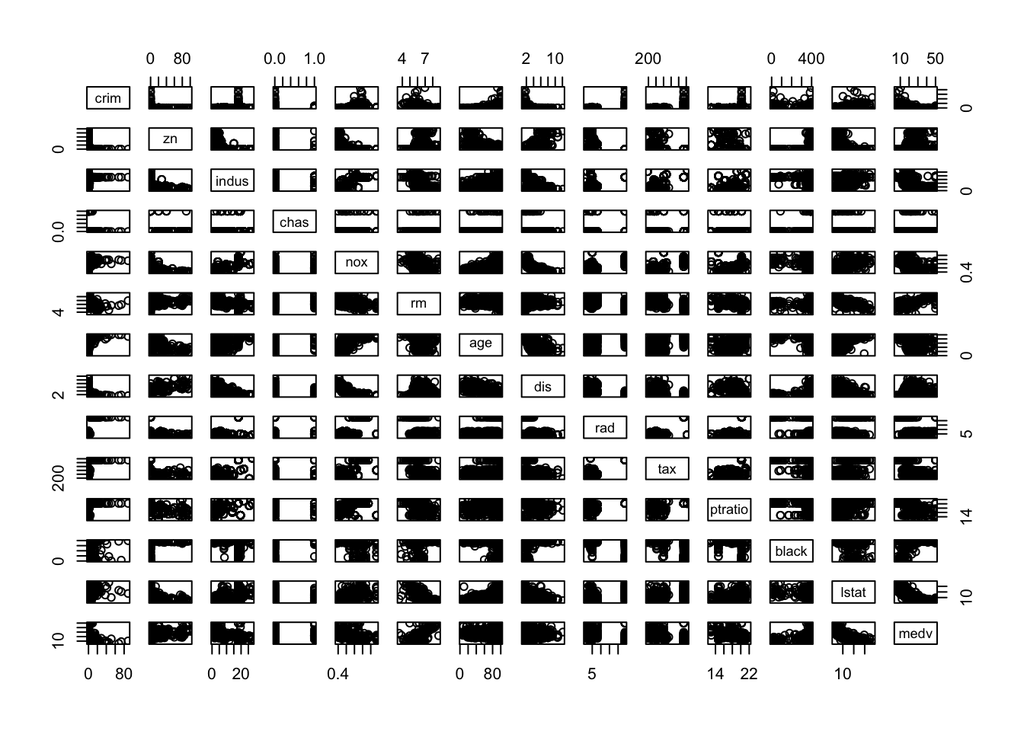

We notice a clear relationship between the home value and % lower status population. We see some areas with no crime, and those are zoned for larger lots.

3. Plots of crime rate versus other predictors:

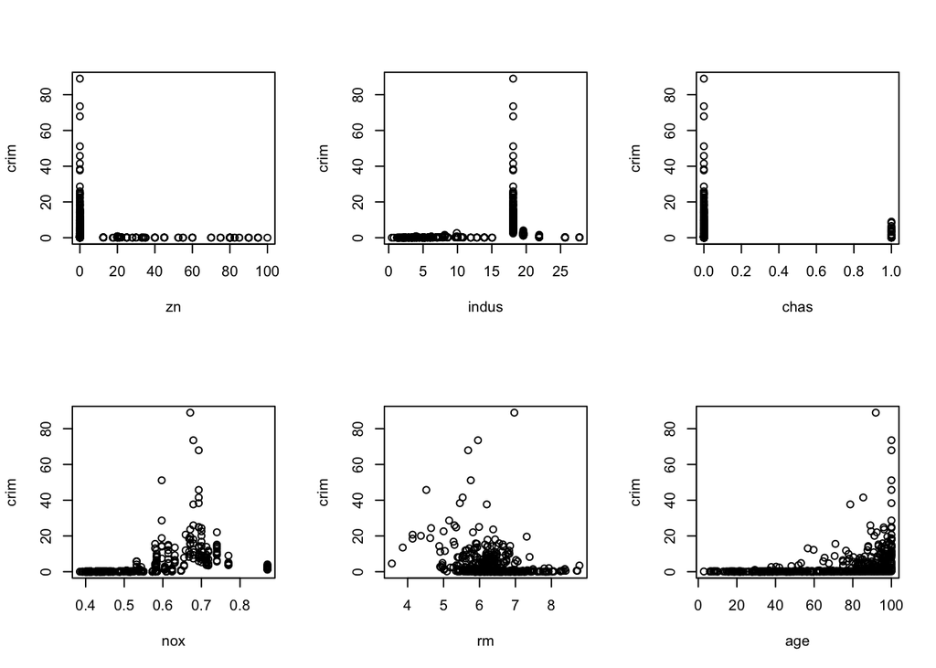

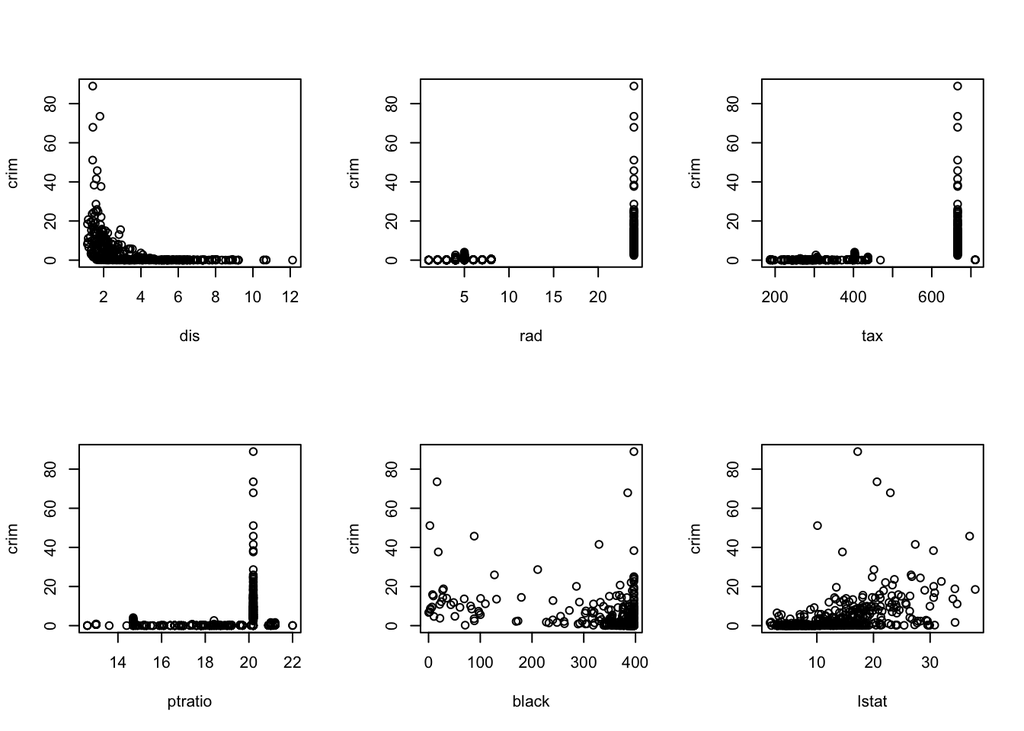

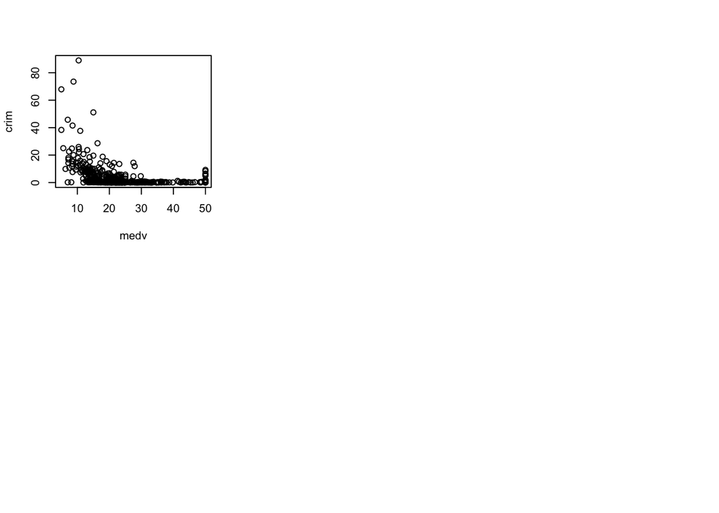

```r
par(mfrow = c(2,3))
for (i in 2:ncol(Boston)){
  plot(Boston[ ,i], crim, xlab = colnames(Boston)[i])
}
```

We see crime is associated with access to the highway, no tract bounds river, high property tax rate, high pupil to teacher ratio.